# Installation Guide

Hello and welcome to the introductory `R` course at the PuG 2021! Before the actual workshops starts, I would like you to set up a few things on your computer. I would like to spend as much time as possible with actual coding during the workshop, and since installing things always takes up a bit of time, we’ll frontload that bit. Think of it as your personal Hogwarts shopping list - you have to get your robes and your books and your wand and stuff so you’ll be all set to do the real magic once you arrive in Hogwarts.

## Every computer is different

That being said, you all have different setups. You have different computers with different operating systems, and I cannot foresee every little thing that might possibly go wrong when you’re installing everything on your side. But no worries, that’s all part of the process. Should you get stuck at some point, don’t hesitate to shoot me an email. So far, I’ve got `R` running on any computer - I won’t give in to yours ;-) (That being said, my installation guide is written from a Windows 10 perspective.)

You will sometimes hear that people don’t like installing `R` (or any other programming language, for that matter) and dread updating it even more. I’m here to tell you that it’s not that bad at all. In fact, just stripped my computer of every single programme I normally use in my everyday `R`-related workflow so I can go through the setup with you. That should show you that there is no need to worry too much about installing or un-installing your `R`-stuff on your computer. You can’t break anything (nothing that can’t be fixed, at least).

## Your magic abilities - R

Imagine `R` as your magic abilities. Some people might be born with it, but we need to download it at https://www.r-project.org/. Right on the start page, you can find a download link via CRAN (“The Comprehensive R Archive Network”).

```r
knitr::include_graphics("./pics/download_r.png")
```

[output not shown]

When clicking it, you will be asked to choose a CRAN mirror. That sounds a bit obscure. Simply put, the those “mirrors” around the world are servers containing identical information, in this case, the source code, additional packages and all the documentation of R. The advantage is that you can choose a server near your location for better bandwidth, and also, you will always be able to download R, even when one of the servers should be down. Personally, I am convinced it is an actual network of magical mirrors in a fantasy world that act as gateways which can transmit R packages between worlds – and no one has proven me wrong yet. Just pick one near you (anywhere in Germany is perfectly fine) and then download R for your operating system on the next page. What you want is “base `R`”.

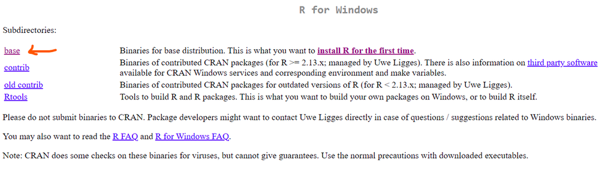

```r
knitr::include_graphics("./pics/base.png")
```

Download R and execute the installation file. Just click through the installation, the default settings are fine.

### Optional for Windows Users: Rtools

If you have windows, it is a good idea to install Rtools as well (mac OS users don’t need it, because your operating system should cover the functionalities Rtools adds on Windows). It is not crucial, so feel free to skip this step. Briefly, Rtools provides tools that are needed on Windows if you want to build `R` packages. Most of the time, you just download and install the package from CRAN, where you get the “binary version” of a package that is ready to be used on your operating system. Sometimes, for some reason, the latest version of a package is not provided as a binary (yet); maybe because it’s just a few days old. In this case, `R` will ask you whether it should “compile” the package from source, i.e. build it on your computer. For this job, Rtools is needed on windows. However, you also have the option not to compile the package and get a (slightly) older version of the package. Which is completely fine – if you don’t want to install Rtools, just hit “no” whenever R asks you whether it should compile a package from source. From time to time, R might throw a warning that Rtools is missing, but no worries - you can just ignore that. If you want to have the option to compile packages and e.g. build packages on your own at some point, then install Rtools. There is no disadvantage of doing that. It can be found on the download page just where we found base `R`. Only this time, we pick Rtools. It is quite likely that you want the 64 bit version. Execute the installation file and just click through.

## The wand - RStudio

We can’t use our magic abilities without a wand (an “editor” in our case). Well, we can, but it is much much less comfortable and powerful. I show you what I mean. Look at this picture: You can see the default editor your get when installing `R`. I’m in the middle of typing a command, and that’s it. `R` doesn’t help me, functionalities are limited and it all looks pretty old school.

[figure not shown]

The default editor for R is not very comfortable to handle.

```r
knitr::include_graphics("./pics/plain_r.png")
```

This, on the other hand, is RStudio, an editor for `R`. It looks a bit wild, because this is an actual screenshot of me working on this installation guide. But what we can see here is that RStudio offers way more than the default editor for `R`: We can easily manage several scripts at once (each of those would be a new window in the default editor), colours help us to read our code, we can easily open files, we can view plots, interact with version control software like GitHub and much, much more. You can also see that, unlike the default editor, RStudio understands that I’m about to use the `mean()` function. It offers me to autocomplete the function for me (so I have to type less) and shows me some information about the function while I’m typing it.

[figure not shown]

RStudio offers us a lot of handy functionalities, like managing several scripts and files at once, viewing plots, using version control tools like Git and displaying information about R functions.

```r
knitr::include_graphics("./pics/rstudio.png")
```

RStudio is not the only editor we can use. However, it is the most popular editor for `R` and it is what we will use during the workshop. What you want to download is the free version of RStudio Desktop here: https://rstudio.com/products/rstudio/download/. Execute the installation file – again, you can just click through. If you open RStudio after the installation, don’t be worried when it doesn’t look like the screenshot above. I customised the appearance of my RStudio because this is the way I like it. Don’t hesitate to play around under **Tools** $\to$ **Global Options** $\to$ **Appearance**.

## Time Travel: Git

One of the things we will learn in our workshop is time travel. For this, we will need a time turn- err, Git. Git enables us to use “version control” (read: time travel), which basically means that every change we made in a file is saved in a history. That does not only allow us to document the things we have changed, we can also go back in time to previous versions of our work in case we messed up. We will learn more about how Git works during the workshop. For now, I just want you to get everything ready so you will be able to use it later.

First of all, create an account on https://github.com/. Next, download Git at https://git-scm.com/downloads. You can mostly click through the installation process. However, there is one option in the dialogue that might need some explaining:

[figure not shown]

The main branch of a GitHub repository used to be called “master”. However, acknowledging the racist history behind a lot of terms used in coding, the name has now been changed to “main”.

```r
knitr::include_graphics("./pics/main_master.png")
```

On GitHub, you can work on “branches” (read: alternative timelines) containing different versions/stages of your project. The main branch where the stable (or final) product is stored used to be called “master”. During the Black Lives Matter movement, tech companies around the world started [replacing the “master/slave” terminology](https://www.allaboutcircuits.com/news/how-master-slave-terminology-reexamined-in-electrical-engineering/) widely used in computer science. When you install Git, it now lets you choose the default name of the main branch.

When your installation of Git is finished, you can confirm that everything worked by opening R Studio (make sure to restart R Studio if it was still open during your installation of Git). There should be a pane somewhere, probably on the top right corner, that has a Git tab (don’t mind the stuff below, that won’t look the same for you):

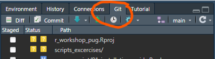

After installing Git, you should find a Git pane in RStudio.

```r
knitr::include_graphics("./pics/git_pane.png")
```

### If that didn’t work

In case that didn’t work for your, you might need to tell RStudio explicitly where to find Git. You can do that under **Tools** $\to$ **Global Options** $\to$ **Git/SVN**.

[figure not shown]

When Git is successfully connected with RStudio, it should look something like this.

```r
knitr::include_graphics("./pics/git_path.png")
```

Make sure that Rstudio know the correct path to Git, i.e. the location where Git is installed (if you’re a Windows user, your path will be similar to the one in the screenshot above). IF you don’t know where you installed Git, you can find out by typing `where git` in the command prompt (just type “command prompt” into the search bar of your computer and it will pop up).

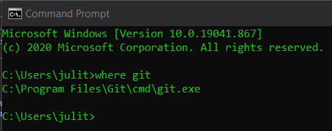

If needed, find out where you installed Git using the command line.

```r
knitr::include_graphics("./pics/shell.png")
```

### Introducing yourself to Git

Git is a little bit shy - it will want to get to know you. Go ahead, introduce yourself! First, open a “shell” by clicking **Tools** $\to$ **Shell**. Git is not really a “point-and-click” thingy, but we will often have to communicate in written commands with it.

To let Git know your user name, type the following command into the shell (**don’t forget to replace `Your Username` with your actual user name!**):

```
git config --global user.name "Your Username"
```

(If you’re trying to copy paste the command into the shell: `Cntrl + C` and `Cntrl + V` won’t work, but a right click will automatically paste the last thing you copied.) You can confirm that everything worked by typing the following, which should report back your user name:

```
git config user.name
```

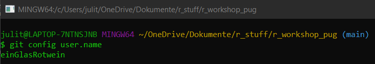

After you’ve introduced yourself, Git will know your name.

```r
knitr::include_graphics("./pics/git_user_name.png")
```

Now set your email using a similar procedure. This time, the command is (**again, don’t forget to replace the email address!**):

```
git config --global user.email "your@email.com"
```

Make sure everything worked by running

```
git config user.email
```

## Aaaaand we’re done!

This is it! You finished all the preparations for the `R` workshop. Thank you for installing everything in advance - that will give us more time to spend with `R` during the workshop. Please write me an email and tell me whether the installation worked for you. I am looking forward to seeing you all at the PuG!

# Creating an R project

## Find a place for your R stuff

You want to be able to easily find your code on your computer. It sounds trivial, but you should have a folder for every project that you do. And by “project” I don’t necessarily mean a full-blown scientific project - it might just be some lines of code that you want to try out. For example, I have a little project that is called *toying_around*, where I save little bits and pieces of code that I’ve tried out and that don’t really belong anywhere.

For example, you might want to create a folder named *my_r_projects* on your computer. Get used to avoiding spaces or any other “funny characters” in your folder names (e.g. German “Umlaute”). We want to open these folders using `R`, using machine-readable commands. And machines are really bad at reading things that contain spaces or any other unexpected characters.

This folder will be filled with all your `R` projects. You might prefer a different structure, that is completely up to you. However, you need to make a decision about where to put your future `R` projects - and what we will do in this workshop will live in one of these projects.

By the way, you can find amazing tips for folder structure, file naming and `R` projects in these slides by [Danielle Navarro](https://slides.djnavarro.net/project-structure/#1).

## Create your first project

After you decided where you want to put your `R` stuff, we should create our first project which will contain everything you do during this workshop. However, we will not create another folder for this workshop right away. Remember that we want to use version control (time travel) throughout this workshop, because I want you to get used to it right from the beginning. That means we will start by creating a new repository on GitHub.[^1] Everything you do will be backed up there and you will always be able to restore previous versions of your script. It is also a great way of tracking how much you actually achieved within these two days! Log in to GitHub and create a new repository with the big green “new” button.

[figure not shown]

Choose a name for your repository, e.g. *pug_2021_r_workshop*. You can also provide a short description for your repository, e.g. something like “This repository contains my coding exercises at the PuG 2021 R workshop.” Your repository can be private, which means only you will be able to see it, or public, which means everyone will be able to see it. If you make it public, it will be much easier for me and other participants of the workshop to collaborate with you, but of course, the decision is up to you. You can add a README file - this file will be shown at the front page of your repository, providing information to everyone visiting. By default, it will contain your repository’s title and the description from above (if you made one). You can also add a **gitignore** - this is a very useful thing to have because it determines what you want to be on GitHub - and what not. You might e.g. want to tell GitHub that it should ignore the raw data file in your project, because you don’t want to upload any sensitive data or simply because the file is too large to be uploaded. If you tick the gitignore box, you can use a gitignore template that has some default settings for `R` - just select `R` from the dropdown list. Lastly, you can set a licence that determines if and how other people can use your code. You can read up about what those licences mean later, but for our workshop, we won’t use any. Great, now hit that create button!

[figure not shown]

Now let’s get this repository to your computer.. In RStudio, go to **File** $\to$ **New Project …** and this is what you should see:

[figure not shown]

We want to use GitHub, which is, as you know, a form of **version control**. So this is what we’ll pick. Next, choose **Git**. RStudio will then ask you for a repository URL and where to save the repository on your computer. Just put in the link to your repository (copy it from your browser) - `R` will then detect the repository name and use that name for the corresponding folder on your computer. You can of course change that name, but I strongly advise not to do that, because it will lead to **A LOT** of confusion. Lastly, `R` asks you in which folder your new repository folder should be saved. In my case, this folder is called `r_stuff`, because this is where all my `R` stuff is saved.

[figure not shown]

You will find that RStudio created a folder with the same name as your repository in at the place where you told it to put it.

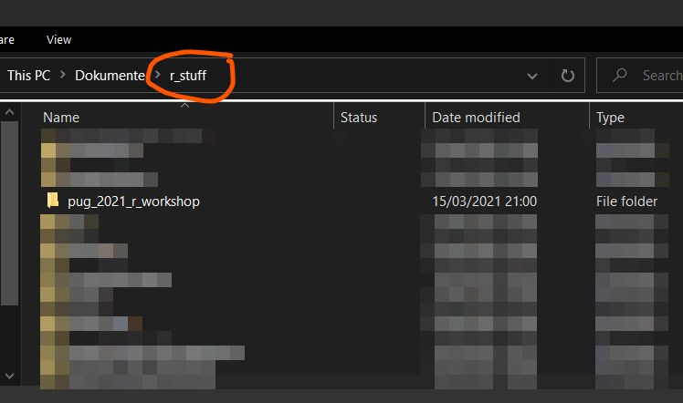

Look inside. The folder contains a gitignore and a README file - no surprise, we created those when we created the repository. But there is also an `R` project file.

Those projects are really useful and we will always use them throughout this workshop. To see how projects work and why they are so powerful, we create a little `R` script first. If RStudio did not open a script for you already, do so with **File** $\to$ **New File** $\to$ **R Script**. For now, just type “Hello world” into the script and save it by clicking the little save icon. (Why [“Hello world”](https://en.wikipedia.org/wiki/%22Hello,_World!%22_program), you ask?)

Check your folder again. You will notice that your script was automatically saved there. This is because when using a project, you will always be in the location where your project file lies. It basically works like the “you are here” icon on a map. It is quite handy that we don’t have to look for the folder we want every time we create and save a new script.

However, your script is now probably named *Untitled1.R*. This is not a good name because you don’t really know what it contains. We should have saved it using **File** $\to$ **Save as …** (maybe under the name *hello_world.R*), but we can just rename it by clicking **File** $\to$ **Rename**. Close RStudio for now.

Head back to your project folder and double click on the Rproject file belonging to your project. You will notice that once again, you are in your project folder that contains the script you created earlier. There should be a **Files** panel in your RStudio where you can see everything that your project folder contains.

[figure not shown]

## Project-oriented workflow

# Basics in R

First, you need to understand some basic principles about `R` - or about programming languages in general. You already know that we usually don’t click buttons - we type commands into `R`. To see how that works, we’ll first take a look at the console. For starters, type in any number and hit return. What happens?

[^1]: There are other ways to use version control, e.g. you *could* start with creating a folder first, but we will not go through all the possibilities in this workshop. I think the procedure I show you is the easiest one, but it is certainly not the only way.